```python
# Mohammad Mahdi Abdolhosseini
# 810 198 434
# AI : CA4 - Machine Learning
```

```python
import numpy as np
import matplotlib.pyplot as plt
import pandas as pd
from scipy.stats import norm
from scipy import stats

from sklearn.model_selection import train_test_split
from sklearn.neighbors import KNeighborsClassifier

from sklearn.metrics import accuracy_score
from sklearn.metrics import confusion_matrix
from sklearn.metrics import classification_report
from sklearn import tree

from sklearn.model_selection import GridSearchCV
from sklearn.linear_model import LogisticRegression
from sklearn.ensemble import RandomForestClassifier
```

# بررسی مجموعه داده

```python
diabetesDataFrame = pd.read_csv ('diabetes.csv')
diabetesDataFrame.head()
```

|  | Pregnancies | Glucose | BloodPressure | SkinThickness | Insulin | BMI | DiabetesPedigreeFunction | Age | Outcome |
| --- | --- | --- | --- | --- | --- | --- | --- | --- | --- |
| 0 | 6.0 | 148.0 | 72.0 | 35.0 | 0.0 | 33.6 | 0.627 | 50.0 | 1 |
| 1 | 1.0 | 85.0 | 66.0 | 29.0 | 0.0 | 26.6 | 0.351 | 31.0 | 0 |
| 2 | NaN | 183.0 | 64.0 | 0.0 | 0.0 | 23.3 | 0.672 | 32.0 | 1 |
| 3 | 1.0 | 89.0 | 66.0 | 23.0 | 94.0 | 28.1 | 0.167 | 21.0 | 0 |
| 4 | NaN | 137.0 | 40.0 | 35.0 | 168.0 | NaN | NaN | 33.0 | 1 |

### سوال اول:

ابتدا ساختار کلی داده ها را با متدهای اینفو و دیسکرایب بدست میاوریم

```python
diabetesDataFrame.info()
```

```
<class 'pandas.core.frame.DataFrame'>
RangeIndex: 768 entries, 0 to 767
Data columns (total 9 columns):
Pregnancies                 635 non-null float64
Glucose                     654 non-null float64
BloodPressure               680 non-null float64
SkinThickness               624 non-null float64
Insulin                     680 non-null float64
BMI                         684 non-null float64
DiabetesPedigreeFunction    590 non-null float64
Age                         655 non-null float64
Outcome                     768 non-null int64
dtypes: float64(8), int64(1)
memory usage: 54.1 KB
```

```python
diabetesDataFrame.describe()
```

|  | Pregnancies | Glucose | BloodPressure | SkinThickness | Insulin | BMI | DiabetesPedigreeFunction | Age | Outcome |
| --- | --- | --- | --- | --- | --- | --- | --- | --- | --- |
| count | 635.000000 | 654.000000 | 680.000000 | 624.000000 | 680.000000 | 684.000000 | 590.000000 | 655.000000 | 768.000000 |
| mean | 3.700787 | 113.422018 | 68.786765 | 20.386218 | 80.123529 | 32.083626 | 0.466676 | 33.157252 | 0.348958 |
| std | 3.518126 | 202.816831 | 19.724841 | 15.987049 | 115.681140 | 7.800741 | 0.322408 | 13.829831 | 0.476951 |
| min | -22.000000 | -5000.000000 | -2.000000 | 0.000000 | 0.000000 | 0.000000 | 0.078000 | -150.000000 | 0.000000 |
| 25% | 1.000000 | 99.000000 | 62.000000 | 0.000000 | 0.000000 | 27.375000 | 0.243250 | 24.000000 | 0.000000 |
| 50% | 3.000000 | 117.000000 | 72.000000 | 23.000000 | 34.000000 | 32.300000 | 0.368000 | 29.000000 | 0.000000 |
| 75% | 6.000000 | 140.750000 | 80.000000 | 32.000000 | 129.250000 | 36.600000 | 0.611500 | 41.000000 | 1.000000 |
| max | 17.000000 | 199.000000 | 122.000000 | 99.000000 | 846.000000 | 67.100000 | 2.329000 | 81.000000 | 1.000000 |

### سوال چهارم: (پیش پردازش مجموعه داده)

از آنجا که تمامی داده ها از نوع عددی هستند در این پروژه نیازی به لیبل زنی به ویژگی های دسته ای نیست. در کل اگر از این قبیل داده های دسته ای داشتیم میتوانستیم از متدهای لیبل انکودینگ و یا وان هات انکودینگ استفاده کنیم

### سوال دوم:

برای هر ویژگی تعداد و نسبت داده های از دست رفته بصورت زیر میباشد

```python
diabetes_NaN = diabetesDataFrame.isnull().sum()
diabetes_NaN
```

```
Pregnancies                 133
Glucose                     114
BloodPressure                88
SkinThickness               144
Insulin                      88
BMI                          84
DiabetesPedigreeFunction    178
Age                         113
Outcome                       0
dtype: int64
```

```python
diabetes_NaN_Ratio = diabetesDataFrame.isnull().sum() / diabetesDataFrame.shape[0]
diabetes_NaN_Ratio
```

```
Pregnancies                 0.173177
Glucose                     0.148438
BloodPressure               0.114583
SkinThickness               0.187500
Insulin                     0.114583
BMI                         0.109375
DiabetesPedigreeFunction    0.231771
Age                         0.147135
Outcome                     0.000000
dtype: float64
```

برای هر ویژگی مد و تعداد آنرا پیدا میکنیم. با بررسی این مقادیر میتوانیم به تصمیم بهتری برای مواجهه با داده های خالی برسیم. مثلا اگر داده ای خیلی تکرار بالایی داشت، شاید بد نباشد داده های خالی آن ویژگی را با مد پر کنیم. اما اگر تعداد تکرار کم بود آن را با میانگین پر میکنیم

```python
for i in diabetesDataFrame.columns:
    print(str(float(stats.mode(diabetesDataFrame[i])[0])) + '\t' + str(float(stats.mode(diabetesDataFrame[i])[1])))
```

```
1.0	114.0
99.0	17.0
70.0	49.0
0.0	186.0
0.0	329.0
31.2	12.0
0.207	5.0
22.0	65.0
0.0	500.0
```

وابستگی ویژگی ها به دیابتی بودن یا نبودن را بررسی میکنیم. قبل از حذف داده های نال و غیر منطقی، نمودار وابستگی ویژگی ها بصورت زیر خواهد بود

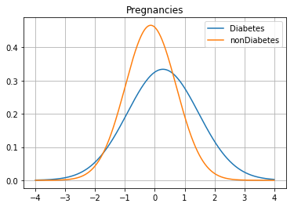

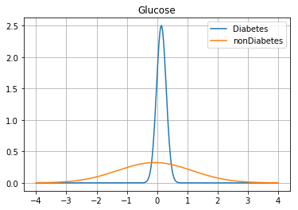

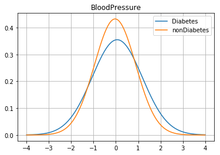

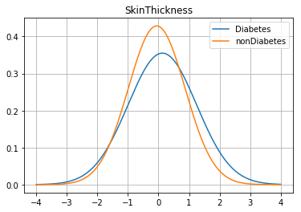

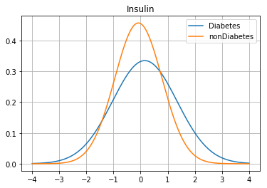

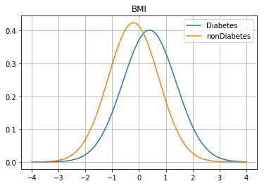

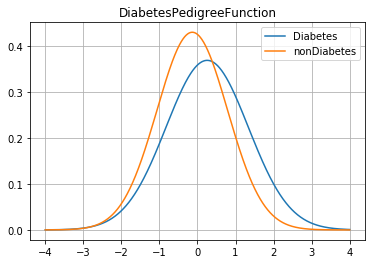

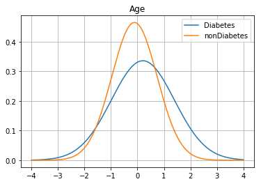

```python
column_header = diabetesDataFrame.columns.tolist()
column_header.remove('Outcome')
df = diabetesDataFrame.copy()

for i in column_header :
    # نرمالیزه کردن
    df[i] = (df[i]-df[i].mean())/df[i].std()

    # میانگین و انحراف معیار افراد دیابتی
    Diabetes_mean = df[df['Outcome'] == 1][i].mean()
    Diabetes_std  = df[df['Outcome'] == 1][i].std()

    # میانگین و انحراف معیار افراد غیر دیابتی
    nonDiabetes_mean = df[df['Outcome'] == 0][i].mean()
    nonDiabetes_std  = df[df['Outcome'] == 0][i].std()

    # بدست آوردن تابع چگالی احتمال، برای هر یک از گروه ها
    x = np.linspace(-4, 4, 1000)
    y_Diabetes = norm.pdf(x, Diabetes_mean, Diabetes_std)
    y_nonDiabetes = norm.pdf(x, nonDiabetes_mean, nonDiabetes_std)

    # رسم نمودار
    plt.plot(x, y_Diabetes, label = 'Diabetes')
    plt.plot(x, y_nonDiabetes, label = 'nonDiabetes')
    #plt.scatter(x, y_Diabetes)
    #plt.hexbin(x, y_Diabetes)
    plt.title(i)
    plt.grid()
    plt.legend()
    plt.show()
```

# پیش پردازش مجموعه داده

### سوال اول:

در ادامه برای حل مشکل مقادیر از دست رفته، دو راه در پیش داریم. یکی اینکه کل ستون را حذف کنیم که در این صورت ممکن است آن ستون حاوی اطلاعات خوبی باشد که با اینکار آنها را نیز از دست میدهیم. راه دوم این است که مقادیر خالی را با آماره ها برای مثال مد یا میانگین پر کنیم. در این صورت هیچ دیتایی از بین نمیرود اما حالت بدی که ممکن است رخ دهد این است که اطلاعات زیادی خالی باشد و ما حجم زیادی را داده سازی کنیم و دیتای بی معنی زیادی تولید کنیم

### سوال دوم:

نمودار وابستگی ویژگی ها را پس جایگذاری مقادیر خالی مجددا رسم میکنیم

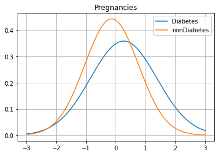

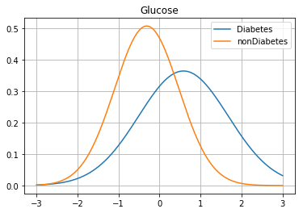

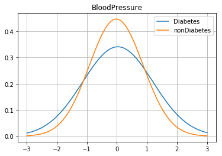

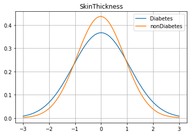

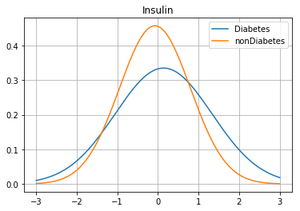

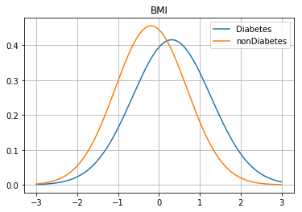

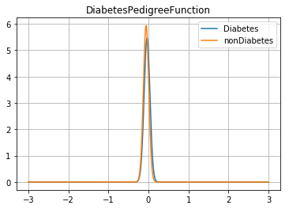

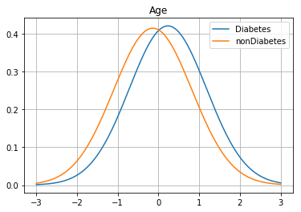

```python
df = diabetesDataFrame.copy()

for i in column_header:
    # find mode to replace the garbage values
    mode = stats.mode(diabetesDataFrame[i])

    # if any data was less than zero, replace it with mode value
    df[df[i] < 0] = float(mode[0])

    # if number of mode > 15% total Size, using mode to replace the NaN values. otherwise, replace it with mean
    if float(mode[1]) > 0.15 * diabetesDataFrame.shape[0]:
        df[i] = df[i].fillna(float(mode[0]))
    else: df[i] = df[i].fillna(df[i].mean())


    # نرمالیزه کردن
    df[i] = (df[i]-df[i].mean())/df[i].std()

    # میانگین و انحراف معیار افراد دیابتی
    Diabetes_mean = df[df['Outcome'] == 1][i].mean()
    Diabetes_std  = df[df['Outcome'] == 1][i].std()

    # میانگین و انحراف معیار افراد غیر دیابتی
    nonDiabetes_mean = df[df['Outcome'] == 0][i].mean()
    nonDiabetes_std  = df[df['Outcome'] == 0][i].std()

    # بدست آوردن تابع چگالی احتمال، برای هر یک از گروه ها
    x = np.linspace(-3, 3, 1000)
    y_Diabetes = norm.pdf(x, Diabetes_mean, Diabetes_std)
    y_nonDiabetes = norm.pdf(x, nonDiabetes_mean, nonDiabetes_std)

    # رسم نمودار
    plt.plot(x, y_Diabetes, label = 'Diabetes')
    plt.plot(x, y_nonDiabetes, label = 'nonDiabetes')
    #plt.scatter(x, y_Diabetes)
    #plt.hexbin(x, y_Diabetes)
    plt.title(i)
    plt.grid()
    plt.legend()
    plt.show()
```

### سوال پنجم:

DiabetesPedigreeFunction بیشترین تعداد داده خالی را داشت و ما با داده سازی بیشترین تغییر را برای این ویژگی نسبت به حالت قبلی شاهد هستیم. بنابراین شاید بهتر باشد کلا ستون این ویژگی را حذف کنیم

```python
df = df.drop('DiabetesPedigreeFunction', axis=1)
```

داده ها را بصورت تصادفی تقسیم بندی میکنیم. مثلا پانزده درصد را برای تست انتخاب میکنیم. برای تقسیم بندی از متد زیر استفاده میکنیم

```python
x = df.drop(["Outcome"], axis=1).values
y = df["Outcome"].values
x_train, x_test, y_train, y_test = train_test_split(x, y, test_size = 0.15, shuffle=True)
```

# آموزش، ارزیابی و تنظیم

### KNN

```python
for i in range(1,102,20):
    knn = KNeighborsClassifier(n_neighbors = i)
    knn.fit(x_train, y_train)
    y_pred = knn.predict(x_test)
    print("n_neighbors = " + str(i))
    print("accuracy of the model = " + str(knn.score(x_test, y_test)*100) + " %")
    print("confusion matrix :\n" + str(confusion_matrix(y_test,y_pred)))
    print(classification_report(y_test, y_pred))
```

```
n_neighbors = 1
accuracy of the model = 70.6896551724138 %
confusion matrix :
[[63 12]
 [22 19]]
             precision    recall  f1-score   support

        0.0       0.74      0.84      0.79        75
        1.0       0.61      0.46      0.53        41

avg / total       0.70      0.71      0.70       116

n_neighbors = 21
accuracy of the model = 73.27586206896551 %
confusion matrix :
[[67  8]
 [23 18]]
             precision    recall  f1-score   support

        0.0       0.74      0.89      0.81        75
        1.0       0.69      0.44      0.54        41

avg / total       0.73      0.73      0.71       116

n_neighbors = 41
accuracy of the model = 72.41379310344827 %
confusion matrix :
[[68  7]
 [25 16]]
             precision    recall  f1-score   support

        0.0       0.73      0.91      0.81        75
        1.0       0.70      0.39      0.50        41

avg / total       0.72      0.72      0.70       116

n_neighbors = 61
accuracy of the model = 75.0 %
confusion matrix :
[[71  4]
```

[output cut: 16 more lines]

```
        1.0       0.94      0.39      0.55        41

avg / total       0.82      0.78      0.74       116

n_neighbors = 101
accuracy of the model = 77.58620689655173 %
confusion matrix :
[[74  1]
 [25 16]]
             precision    recall  f1-score   support

        0.0       0.75      0.99      0.85        75
        1.0       0.94      0.39      0.55        41

avg / total       0.82      0.78      0.74       116
```

### Decision Tree

```python
for i in range(1,102,20):
    # Create Decision Tree classifer object
    clf = tree.DecisionTreeClassifier(max_depth = i)
    # Train Decision Tree Classifer
    clf = clf.fit(x_train, y_train)
    #Predict the response for test dataset
    y_pred = clf.predict(x_test)
    # Model Accuracy, how often is the classifier correct?
    print("max_depth = " + str(i))
    print("Accuracy:", accuracy_score(y_test, y_pred))
    print()
```

```
max_depth = 1
Accuracy: 0.7068965517241379

max_depth = 21
Accuracy: 0.7155172413793104

max_depth = 41
Accuracy: 0.7155172413793104

max_depth = 61
Accuracy: 0.7327586206896551

max_depth = 81
Accuracy: 0.6896551724137931

max_depth = 101
Accuracy: 0.7068965517241379
```

#### max_depth:

در این مدل در ابتدا مدل ما دچار آندرفیت است چون متغیر ماکسیمم عمق، مقدار بسیار کمی دارد ولی با افزایش این هایپر پارامتر دقت ما افزایش پیدا میکند. ولی همانطور که مشاهده میشود از اواسط کار، این هایپر پارامتر بیش از حد زیاد میشود و مدل دچار اورفیت میشود و دقت آن کاهش پیدا میکند

```python
for i in range(1,102,20):
    # Create Decision Tree classifer object
    clf = tree.DecisionTreeClassifier(min_samples_leaf = i)
    # Train Decision Tree Classifer
    clf = clf.fit(x_train, y_train)
    #Predict the response for test dataset
    y_pred = clf.predict(x_test)
    # Model Accuracy, how often is the classifier correct?
    print("min_samples_leaf = " + str(i))
    print("Accuracy:", accuracy_score(y_test, y_pred))
    print()
```

```
min_samples_leaf = 1
Accuracy: 0.6551724137931034

min_samples_leaf = 21
Accuracy: 0.6637931034482759

min_samples_leaf = 41
Accuracy: 0.6810344827586207

min_samples_leaf = 61
Accuracy: 0.6982758620689655

min_samples_leaf = 81
Accuracy: 0.7241379310344828

min_samples_leaf = 101
Accuracy: 0.7068965517241379
```

#### min samples leaf:

```python
max_depth_range = range(1,20)
min_samples_leaf_range = range(1,100)
tree_param = {'criterion': ['entropy', 'gini'], 'max_depth': max_depth_range}
clf = GridSearchCV(tree.DecisionTreeClassifier(), tree_param, cv=5)
clf = clf.fit(x_train, y_train)
y_pred = clf.predict(x_test)
print(clf.best_params_)

tree_param = {'criterion': ['entropy', 'gini'], 'min_samples_leaf': min_samples_leaf_range}
clf = GridSearchCV(tree.DecisionTreeClassifier(), tree_param, cv=5)
clf = clf.fit(x_train, y_train)
y_pred = clf.predict(x_test)
print(clf.best_params_)
```

```
C:\Program Files (x86)\Microsoft Visual Studio\Shared\Anaconda3_64\lib\site-packages\sklearn\model_selection\_split.py:605: Warning: The least populated class in y has only 1 members, which is too few. The minimum number of members in any class cannot be less than n_splits=5.
  % (min_groups, self.n_splits)), Warning)
```

```
{'criterion': 'entropy', 'max_depth': 3}
```

```
C:\Program Files (x86)\Microsoft Visual Studio\Shared\Anaconda3_64\lib\site-packages\sklearn\model_selection\_split.py:605: Warning: The least populated class in y has only 1 members, which is too few. The minimum number of members in any class cannot be less than n_splits=5.
  % (min_groups, self.n_splits)), Warning)
```

```
{'criterion': 'entropy', 'min_samples_leaf': 92}
```

```python
# Create Decision Tree classifer object
clf = tree.DecisionTreeClassifier(min_samples_leaf = 92, max_depth = 3)
# Train Decision Tree Classifer
clf = clf.fit(x_train, y_train)
#Predict the response for test dataset
y_pred = clf.predict(x_test)
# Model Accuracy, how often is the classifier correct?
print("max_depth = " + str(3))
print("min_samples_leaf = " + str(92))
print("Accuracy:", accuracy_score(y_test, y_pred))
print("confusion matrix :\n" + str(confusion_matrix(y_test,y_pred)))
print(classification_report(y_test, y_pred))
```

```
max_depth = 3
min_samples_leaf = 92
Accuracy: 0.7068965517241379
confusion matrix :
[[68  7]
 [27 14]]
             precision    recall  f1-score   support

        0.0       0.72      0.91      0.80        75
        1.0       0.67      0.34      0.45        41

avg / total       0.70      0.71      0.68       116
```

### Logistic Regression

```python
clf = LogisticRegression(random_state=16)
clf.fit(x_train, y_train)
y_pred = clf.predict(x_test)
# Model Accuracy
print("Accuracy:", accuracy_score(y_test, y_pred))
print("confusion matrix :\n" + str(confusion_matrix(y_test,y_pred)))
print(classification_report(y_test, y_pred))
```

```
Accuracy: 0.7586206896551724
confusion matrix :
[[69  6]
 [22 19]]
             precision    recall  f1-score   support

        0.0       0.76      0.92      0.83        75
        1.0       0.76      0.46      0.58        41

avg / total       0.76      0.76      0.74       116
```

### Random Forest

```python
for i in range(1,102,20):
    # Create Random Forest classifer object
    clf = RandomForestClassifier(n_estimators = 300, max_depth = 15, min_samples_leaf = i)
    # Train Random Forest Classifer
    clf = clf.fit(x_train, y_train)
    #Predict the response for test dataset
    y_pred = clf.predict(x_test)
    # Model Accuracy, how often is the classifier correct?
    print("min_samples_leaf = " + str(i))
    print("Accuracy:", accuracy_score(y_test, y_pred))
    print()
```

```
min_samples_leaf = 1
Accuracy: 0.7672413793103449

min_samples_leaf = 21
Accuracy: 0.7241379310344828

min_samples_leaf = 41
Accuracy: 0.7413793103448276

min_samples_leaf = 61
Accuracy: 0.7413793103448276

min_samples_leaf = 81
Accuracy: 0.7413793103448276

min_samples_leaf = 101
Accuracy: 0.7241379310344828
```

```python
for i in range(1,102,20):
    # Create Random Forest classifer object
    clf = RandomForestClassifier(n_estimators = 300, max_depth = i, min_samples_leaf = 15)
    # Train Random Forest Classifer
    clf = clf.fit(x_train, y_train)
    #Predict the response for test dataset
    y_pred = clf.predict(x_test)
    # Model Accuracy, how often is the classifier correct?
    print("max_depth = " + str(i))
    print("Accuracy:", accuracy_score(y_test, y_pred))
    print()
```

```
max_depth = 1
Accuracy: 0.6724137931034483

max_depth = 21
Accuracy: 0.7327586206896551

max_depth = 41
Accuracy: 0.7155172413793104

max_depth = 61
Accuracy: 0.7068965517241379

max_depth = 81
Accuracy: 0.7155172413793104

max_depth = 101
Accuracy: 0.7155172413793104
```

#### max_depth:

این متغیر حداکثر ارتفاع هر درخت در جنگل را مشخص میکند. افزایش این متغیر باعث میشود مدل ما بیشتر با داده ترین فیت شود و در نتیجه محدود کردن آن باعث کمتر شدن واریانس و افزایش بایاس میشود

#### min_samples_leaf:

تاثیر این متغیر نیز مانند متغیر بالاست، با این تفاوت که افزایش آن باعث کمتر فیت شدن درخت با داده ترین میشود و باعث واریانس کمتر و بایاس بیشتر میشود

#### n_estimators:

این متغیر درخت های داخل جنگل را نشان میدهد. افزایش آن باعث افزایش محاسبات و کندی برنامه میشود. البته افزایش این متغیر همیشه به بهبود نتیجه منتهی نمیشود، چرا که افزایش بیش از حد آن ممکن است باعث شود درخت ها به هم وابستگی پیدا کنند که این اتفاق باعث کاهش دقت میشود

```python
max_depth_range = range(1,20)
min_samples_leaf_range = range(1,100)
tree_param = {'criterion': ['entropy', 'gini'], 'max_depth': max_depth_range}
clf = GridSearchCV(RandomForestClassifier(), tree_param, cv=5)
clf = clf.fit(x_train, y_train)
y_pred = clf.predict(x_test)
print(clf.best_params_)

tree_param = {'criterion': ['entropy', 'gini'], 'min_samples_leaf': min_samples_leaf_range}
clf = GridSearchCV(RandomForestClassifier(), tree_param, cv=5)
clf = clf.fit(x_train, y_train)
y_pred = clf.predict(x_test)
print(clf.best_params_)
```

```
C:\Program Files (x86)\Microsoft Visual Studio\Shared\Anaconda3_64\lib\site-packages\sklearn\model_selection\_split.py:605: Warning: The least populated class in y has only 1 members, which is too few. The minimum number of members in any class cannot be less than n_splits=5.
  % (min_groups, self.n_splits)), Warning)
```

```
{'criterion': 'gini', 'max_depth': 3}
```

```
C:\Program Files (x86)\Microsoft Visual Studio\Shared\Anaconda3_64\lib\site-packages\sklearn\model_selection\_split.py:605: Warning: The least populated class in y has only 1 members, which is too few. The minimum number of members in any class cannot be less than n_splits=5.
  % (min_groups, self.n_splits)), Warning)
```

```
{'criterion': 'gini', 'min_samples_leaf': 23}
```

```python
# Create Random Forest classifer object
clf = RandomForestClassifier(n_estimators = 300, max_depth = 3, min_samples_leaf = 23)
# Train Random Forest Classifer
clf = clf.fit(x_train, y_train)
#Predict the response for test dataset
y_pred = clf.predict(x_test)
# Model Accuracy, how often is the classifier correct?
print("max_depth = " + str(3))
print("min_samples_leaf = " + str(23))
print("Accuracy:", accuracy_score(y_test, y_pred))
print("confusion matrix :\n" + str(confusion_matrix(y_test,y_pred)))
print(classification_report(y_test, y_pred))
```

```
max_depth = 3
min_samples_leaf = 23
Accuracy: 0.75
confusion matrix :
[[70  5]
 [24 17]]
             precision    recall  f1-score   support

        0.0       0.74      0.93      0.83        75
        1.0       0.77      0.41      0.54        41

avg / total       0.75      0.75      0.73       116
```

### سوال سوم: (آموزش، ارزیابی و تنظیم)

#### underfitting:

این حالت زمانی اتفاق میوفتد که ما به دلالیل مختلف مانند کم بودن دیتای ترین، بد انتخاب کردن هایپر پارامترها و... نمیتوانیم مدل خود را به خوبی آموزش دهیم و در نتیجه نمیتوانیم به خوبی پیش بینی کنیم و دقت مدل ما کاهش میابد

#### overfitting:

این حالت هنگامی رخ میدهد که ما بیش از حد مدل خود را آموزش میدهیم و در نتیجه حتی نویزها هم مدل میشوند و دقت مدل ما کاهش میابد

### سوال دوم: (روش های یادگیری جمعی)

همانطور که از نتایج پیداست، استفاده از روش های یادگیری جمعی و رای گیری بین آنها سبب افزایش دقت مدل میشود. در بخش درخت تصمیم ما تنها یک درخت داشتیم که ممکن است بایاس داشته باشد جوابش متناسب با داده ترین جهت دار باشد. از این رو اگر ما یک جنگل درخت داشته باشیم میتوانیم به دقت بهتری در مدل دست یابیم